# Project 4

```python
import matplotlib as mpl
import matplotlib.pyplot as plt
import pandas as pd
import scipy.stats
from scipy import stats
import numpy as np
import seaborn as sns
```

The dataset I used for project 4 was straight from kaggle. This dataset contains 2000 female patients and their diabetes data. The columns include:

Pregnancies - Number of times pregnant

Glucose - Plasma glucose concentration a 2 hours in an oral glucose tolerance test

BloodPressure - Diastolic blood pressure (mm Hg)

SkinThickness - Triceps skin fold thickness (mm)

Insulin - 2-Hour serum insulin (mu U/ml)

BMI - Body mass index (weight in kg/(height in m)^2)

DiabetesPedigreeFunction - Diabetes pedigree function

Age - Age (years)

Outcome - Class variable (0 or 1) class value 1 is interpreted as "tested positive for diabetes

For this project, I decided to make a Kmeans decision tree and elbow method for the diabetes dataset.

```python
diabetes= pd.read_csv('diabetes.csv')
```

```python
diabetes.describe()
```

|  | Pregnancies | Glucose | BloodPressure | SkinThickness | Insulin | BMI | DiabetesPedigreeFunction | Age | Outcome |
| --- | --- | --- | --- | --- | --- | --- | --- | --- | --- |
| count | 2000.000000 | 2000.000000 | 2000.000000 | 2000.000000 | 2000.000000 | 2000.000000 | 2000.000000 | 2000.000000 | 2000.000000 |
| mean | 3.703500 | 121.182500 | 69.145500 | 20.935000 | 80.254000 | 32.193000 | 0.470930 | 33.090500 | 0.342000 |
| std | 3.306063 | 32.068636 | 19.188315 | 16.103243 | 111.180534 | 8.149901 | 0.323553 | 11.786423 | 0.474498 |
| min | 0.000000 | 0.000000 | 0.000000 | 0.000000 | 0.000000 | 0.000000 | 0.078000 | 21.000000 | 0.000000 |
| 25% | 1.000000 | 99.000000 | 63.500000 | 0.000000 | 0.000000 | 27.375000 | 0.244000 | 24.000000 | 0.000000 |
| 50% | 3.000000 | 117.000000 | 72.000000 | 23.000000 | 40.000000 | 32.300000 | 0.376000 | 29.000000 | 0.000000 |
| 75% | 6.000000 | 141.000000 | 80.000000 | 32.000000 | 130.000000 | 36.800000 | 0.624000 | 40.000000 | 1.000000 |
| max | 17.000000 | 199.000000 | 122.000000 | 110.000000 | 744.000000 | 80.600000 | 2.420000 | 81.000000 | 1.000000 |

```python
diabetes.head()
```

|  | Pregnancies | Glucose | BloodPressure | SkinThickness | Insulin | BMI | DiabetesPedigreeFunction | Age | Outcome |
| --- | --- | --- | --- | --- | --- | --- | --- | --- | --- |
| 0 | 2 | 138 | 62 | 35 | 0 | 33.6 | 0.127 | 47 | 1 |
| 1 | 0 | 84 | 82 | 31 | 125 | 38.2 | 0.233 | 23 | 0 |
| 2 | 0 | 145 | 0 | 0 | 0 | 44.2 | 0.630 | 31 | 1 |
| 3 | 0 | 135 | 68 | 42 | 250 | 42.3 | 0.365 | 24 | 1 |
| 4 | 1 | 139 | 62 | 41 | 480 | 40.7 | 0.536 | 21 | 0 |

```python
diabetes.shape
```

```
(2000, 9)
```

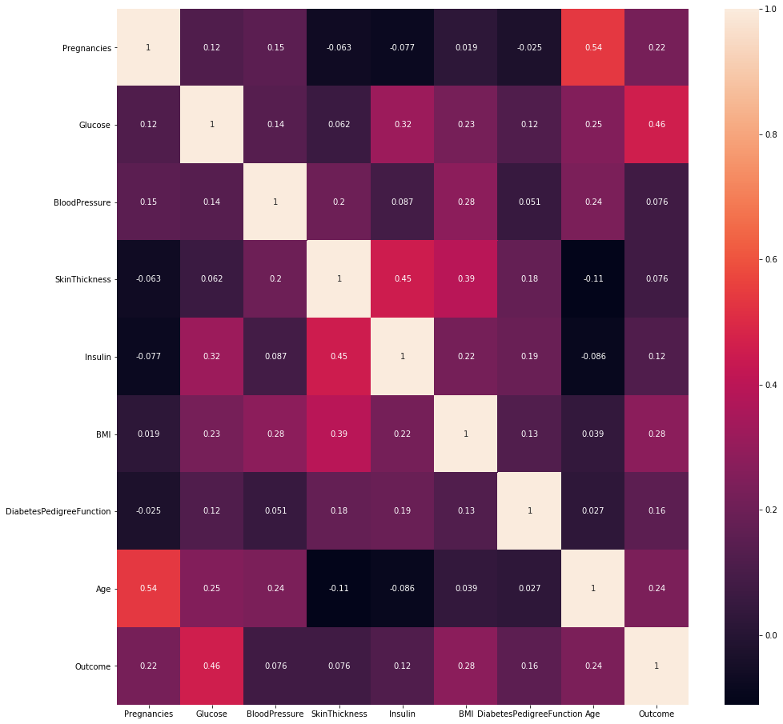

```python
Var_Corr = diabetes.corr()
plt.figure(figsize = (16,16))
sns.heatmap(Var_Corr, xticklabels=Var_Corr.columns, yticklabels=Var_Corr.columns, annot=True)
```

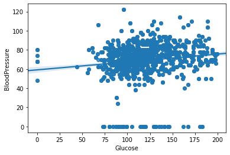

```python
#scatter plot of blood pression vs. cholesterol

sns.regplot(diabetes.Glucose,diabetes.BloodPressure)
```

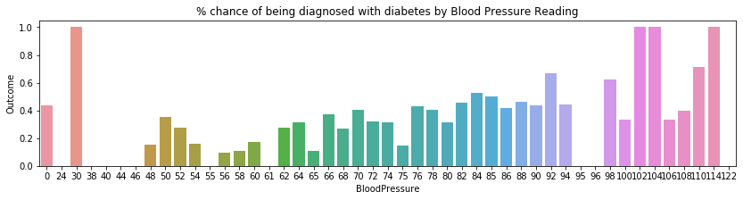

```python
plt.figure(figsize=(14,3))
bp_pivot = diabetes.groupby('BloodPressure').Outcome.mean().reset_index()
sns.barplot(bp_pivot.BloodPressure, bp_pivot.Outcome)
plt.title('% chance of being diagnosed with diabetes by Blood Pressure Reading')
plt.show()
```

```python
# separate the independent variables and dependent variables
# The independent variables are:Glucose, blood pressure
# The dependent variable is: Outcome

X = diabetes.iloc[:, [1,2]].values
y = diabetes.iloc[:,8].values
```

```python
#import scikit_learn and training test
import sklearn as scikit_learn

from sklearn.model_selection import train_test_split
```

```python
# Splitting the dataset into the Training set and Test set

X_train, X_test, y_train, y_test = train_test_split(X, y, test_size = 0.25, random_state = 0)
```

```python
X_train.shape,y_train.shape
```

```
((1500, 2), (1500,))
```

```python
X_test.shape,y_test.shape
```

```
((500, 2), (500,))
```

```python
#utilizing the StandardScaler package for our X train and test
from sklearn.preprocessing import StandardScaler
sc_X = StandardScaler()
X_train = sc_X.fit_transform(X_train)
X_test = sc_X.transform(X_test)
```

```python
X_train
```

```
array([[ 1.69829948,  0.86966378],
       [-0.7539766 , -0.24481351],
       [ 0.05310161, -1.05534245],
       ...,
       [-0.81605953, -0.24481351],
       [-1.12647423,  0.26176708],
       [ 0.45664071,  0.66703154]])
```

```python
X_test
```

[output not shown]

[output cut: 445 more lines]

```
       [-0.4435619 , -0.04218128],
       [-0.35043749, -0.04218128],
       [-0.28835456,  0.16045096],
       [-0.81605953, -0.24481351],
       [ 0.45664071,  0.76834766],
       [ 0.23935042,  2.08545719],
       [-0.47460337,  0.05913484],
       [-1.09543276, -0.14349739],
       [-0.28835456,  0.86966378],
       [ 0.39455777, -0.54876186],
       [-1.46793039, -0.85271022],
       [ 0.08414308, -0.65007798],
       [-0.22627162, -0.04218128],
       [ 0.14622601, -0.44744575],
       [ 2.25704593,  0.56571543]])
```

```python
#fit Decision Tree to training set
from sklearn.tree import DecisionTreeClassifier
classifier = DecisionTreeClassifier()
```

```python
classifier.fit(X_train,y_train)
```

```
DecisionTreeClassifier(class_weight=None, criterion='gini', max_depth=None,
                       max_features=None, max_leaf_nodes=None,
                       min_impurity_decrease=0.0, min_impurity_split=None,
                       min_samples_leaf=1, min_samples_split=2,
                       min_weight_fraction_leaf=0.0, presort=False,
                       random_state=None, splitter='best')
```

```python
# setting our y_predict set
y_pred = classifier.predict(X_test)
```

```python
y_pred
```

```
array([0, 0, 1, 1, 1, 1, 1, 0, 0, 0, 0, 1, 0, 0, 1, 0, 0, 0, 1, 1, 1, 1,
       0, 0, 0, 1, 0, 1, 0, 1, 1, 1, 0, 1, 0, 1, 0, 0, 0, 0, 0, 0, 1, 0,
       1, 1, 1, 0, 1, 1, 0, 0, 0, 0, 0, 0, 0, 0, 0, 0, 0, 0, 0, 0, 0, 0,
       0, 0, 1, 0, 1, 0, 0, 0, 0, 1, 0, 1, 0, 0, 0, 1, 0, 1, 0, 0, 0, 0,
       0, 0, 1, 0, 0, 1, 1, 0, 0, 0, 1, 1, 0, 1, 0, 1, 0, 0, 0, 0, 0, 1,
       1, 1, 0, 0, 0, 1, 0, 0, 1, 0, 1, 0, 0, 0, 0, 0, 0, 1, 0, 0, 0, 0,
       0, 1, 0, 0, 1, 0, 0, 0, 0, 0, 1, 0, 0, 0, 1, 0, 1, 0, 1, 0, 1, 0,
       0, 0, 0, 0, 1, 1, 0, 1, 1, 0, 0, 0, 0, 0, 1, 0, 1, 0, 1, 1, 1, 1,
       0, 1, 0, 0, 0, 0, 0, 0, 0, 1, 0, 1, 0, 1, 0, 1, 1, 0, 1, 0, 0, 1,
       1, 0, 1, 1, 0, 1, 1, 1, 0, 0, 0, 0, 1, 0, 0, 1, 1, 0, 0, 1, 0, 0,
       1, 1, 0, 1, 0, 0, 0, 0, 0, 1, 0, 0, 0, 1, 0, 0, 1, 1, 0, 1, 0, 0,
       1, 1, 0, 0, 1, 0, 0, 1, 1, 0, 0, 1, 0, 1, 0, 0, 0, 1, 1, 0, 1, 1,
       1, 1, 1, 0, 0, 0, 0, 1, 1, 0, 1, 0, 0, 0, 1, 0, 0, 0, 0, 1, 1, 0,
       0, 0, 1, 0, 0, 1, 0, 0, 0, 0, 0, 1, 0, 0, 1, 1, 0, 0, 1, 0, 0, 0,
       0, 0, 0, 0, 0, 1, 0, 0, 1, 1, 0, 0, 0, 0, 0, 0, 0, 0, 0, 0, 0, 0,
       0, 0, 0, 0, 1, 0, 1, 0, 1, 0, 0, 0, 0, 0, 0, 0, 1, 1, 1, 0, 0, 0,
       0, 1, 0, 1, 0, 0, 0, 0, 0, 0, 0, 1, 0, 1, 0, 0, 1, 0, 1, 0, 0, 0,
       1, 0, 0, 1, 0, 0, 0, 0, 1, 0, 0, 1, 0, 0, 0, 1, 1, 0, 0, 1, 0, 1,
       1, 1, 1, 0, 0, 1, 0, 0, 1, 0, 1, 0, 0, 0, 0, 1, 0, 1, 0, 0, 1, 1,
       0, 0, 1, 0, 1, 0, 1, 0, 1, 0, 0, 0, 0, 0, 1, 1, 1, 0, 0, 1, 1, 0,
       0, 1, 0, 0, 0, 0, 0, 1, 0, 0, 0, 1, 0, 1, 0, 0, 0, 0, 0, 1, 0, 1,
       0, 0, 1, 0, 0, 0, 0, 0, 1, 1, 0, 1, 1, 0, 1, 0, 0, 1, 1, 0, 0, 0,
       0, 0, 0, 0, 1, 1, 1, 0, 0, 0, 0, 0, 0, 0, 1, 0], dtype=int64)
```

```python
# confusion matrix
from sklearn.metrics import confusion_matrix
```

```python
confusion_mx = confusion_matrix(y_test,y_pred)
```

```python
confusion_mx
```

```
array([[303,  31],
       [ 24, 142]], dtype=int64)
```

False positive: 31

False negative: 24

```python
classifier.score(X_test,y_test)
```

```
0.89
```

Accuracy of predictor is around 89 percent, very accurate

```python
print( 'The Predicted class %s, The Real class %s' % (classifier.predict(X).reshape(1,-1), y ))
print( 'The probabilities for each class from 0 to 1: %s' % (classifier.predict_proba(X).reshape(1,-1)))
```

```
The Predicted class [[0 0 1 ... 0 0 0]], The Real class [1 0 1 ... 0 1 0]
The probabilities for each class from 0 to 1: [[1. 0. 1. ... 0. 1. 0.]]
```

```python
#The predicted class percentage
classifier.predict(X_test)
```

```
array([0, 0, 1, 1, 1, 1, 1, 0, 0, 0, 0, 1, 0, 0, 1, 0, 0, 0, 1, 1, 1, 1,
       0, 0, 0, 1, 0, 1, 0, 1, 1, 1, 0, 1, 0, 1, 0, 0, 0, 0, 0, 0, 1, 0,
       1, 1, 1, 0, 1, 1, 0, 0, 0, 0, 0, 0, 0, 0, 0, 0, 0, 0, 0, 0, 0, 0,
       0, 0, 1, 0, 1, 0, 0, 0, 0, 1, 0, 1, 0, 0, 0, 1, 0, 1, 0, 0, 0, 0,
       0, 0, 1, 0, 0, 1, 1, 0, 0, 0, 1, 1, 0, 1, 0, 1, 0, 0, 0, 0, 0, 1,
       1, 1, 0, 0, 0, 1, 0, 0, 1, 0, 1, 0, 0, 0, 0, 0, 0, 1, 0, 0, 0, 0,
       0, 1, 0, 0, 1, 0, 0, 0, 0, 0, 1, 0, 0, 0, 1, 0, 1, 0, 1, 0, 1, 0,
       0, 0, 0, 0, 1, 1, 0, 1, 1, 0, 0, 0, 0, 0, 1, 0, 1, 0, 1, 1, 1, 1,
       0, 1, 0, 0, 0, 0, 0, 0, 0, 1, 0, 1, 0, 1, 0, 1, 1, 0, 1, 0, 0, 1,
       1, 0, 1, 1, 0, 1, 1, 1, 0, 0, 0, 0, 1, 0, 0, 1, 1, 0, 0, 1, 0, 0,
       1, 1, 0, 1, 0, 0, 0, 0, 0, 1, 0, 0, 0, 1, 0, 0, 1, 1, 0, 1, 0, 0,
       1, 1, 0, 0, 1, 0, 0, 1, 1, 0, 0, 1, 0, 1, 0, 0, 0, 1, 1, 0, 1, 1,
       1, 1, 1, 0, 0, 0, 0, 1, 1, 0, 1, 0, 0, 0, 1, 0, 0, 0, 0, 1, 1, 0,
       0, 0, 1, 0, 0, 1, 0, 0, 0, 0, 0, 1, 0, 0, 1, 1, 0, 0, 1, 0, 0, 0,
       0, 0, 0, 0, 0, 1, 0, 0, 1, 1, 0, 0, 0, 0, 0, 0, 0, 0, 0, 0, 0, 0,
       0, 0, 0, 0, 1, 0, 1, 0, 1, 0, 0, 0, 0, 0, 0, 0, 1, 1, 1, 0, 0, 0,
       0, 1, 0, 1, 0, 0, 0, 0, 0, 0, 0, 1, 0, 1, 0, 0, 1, 0, 1, 0, 0, 0,
       1, 0, 0, 1, 0, 0, 0, 0, 1, 0, 0, 1, 0, 0, 0, 1, 1, 0, 0, 1, 0, 1,
       1, 1, 1, 0, 0, 1, 0, 0, 1, 0, 1, 0, 0, 0, 0, 1, 0, 1, 0, 0, 1, 1,
       0, 0, 1, 0, 1, 0, 1, 0, 1, 0, 0, 0, 0, 0, 1, 1, 1, 0, 0, 1, 1, 0,
       0, 1, 0, 0, 0, 0, 0, 1, 0, 0, 0, 1, 0, 1, 0, 0, 0, 0, 0, 1, 0, 1,
       0, 0, 1, 0, 0, 0, 0, 0, 1, 1, 0, 1, 1, 0, 1, 0, 0, 1, 1, 0, 0, 0,
       0, 0, 0, 0, 1, 1, 1, 0, 0, 0, 0, 0, 0, 0, 1, 0], dtype=int64)
```

```python
# The Probability of diabetes for each data points

classifier.predict_proba(X_test )
```

[output not shown]

[output cut: 445 more lines]

```
       [1.        , 0.        ],
       [1.        , 0.        ],
       [1.        , 0.        ],
       [0.4       , 0.6       ],
       [0.        , 1.        ],
       [0.        , 1.        ],
       [1.        , 0.        ],
       [1.        , 0.        ],
       [1.        , 0.        ],
       [1.        , 0.        ],
       [1.        , 0.        ],
       [1.        , 0.        ],
       [1.        , 0.        ],
       [0.        , 1.        ],
       [1.        , 0.        ]])
```

```python
from sklearn.multiclass import OneVsRestClassifier, OneVsOneClassifier
from sklearn.cluster import KMeans
OneVsRest = OneVsRestClassifier(classifier).fit(X_train,y_train)
OneVsOne = OneVsOneClassifier(classifier).fit(X_train,y_train)
print( 'One vs Rest accuracy: %.3f' % OneVsRest.score(X_test,y_test) )
print( 'One vs One accuracy: %.3f' % OneVsOne.score(X_test,y_test) )
```

```
One vs Rest accuracy: 0.890
One vs One accuracy: 0.898
```

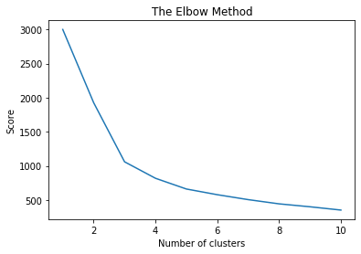

```python
# Fitting K-Means to the dataset
kmeans = KMeans(n_clusters = 2, init = 'k-means++', max_iter=300,n_init=10)
y_kmeans = kmeans.fit_predict(X)

# Using the elbow method to find the optimal number of clusters
from sklearn.cluster import KMeans
score  = []
for cluster in range(1, 11):
    kmeans = KMeans(n_clusters = cluster, init = 'k-means++', max_iter=300,n_init=10)
    kmeans.fit(X)
    score.append(kmeans.inertia_)
plt.plot(range(1, 11), score)
plt.title('The Elbow Method')
plt.xlabel('Number of clusters')
plt.ylabel('Score')
plt.show()
```

```python
#import decision tree classifier
from sklearn import tree
from sklearn.tree import DecisionTreeClassifier, plot_tree
```

```python
n_classes = 2
plot_colors = "rg"
plot_step = 0.02
for pairidx, pair in enumerate([[0, 1], [0, 2], [0, 3],
                                [1, 2], [1, 3], [2, 3]]):

    X = X_train
    y = y_train
```

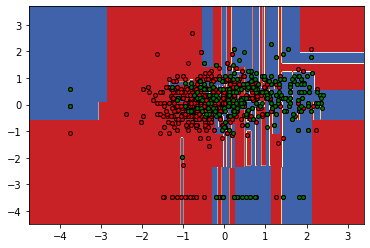

```python
x_min, x_max = X[:, 0].min() - 1, X[:, 0].max() + 1
y_min, y_max = X[:, 1].min() - 1, X[:, 1].max() + 1
xx, yy = np.meshgrid(np.arange(x_min, x_max, plot_step),
                         np.arange(y_min, y_max, plot_step))
plt.tight_layout(h_pad=0.5, w_pad=0.5, pad=2.5)

Z = classifier.predict(np.c_[xx.ravel(), yy.ravel()])
Z = Z.reshape(xx.shape)
cs = plt.contourf(xx, yy, Z, cmap=plt.cm.RdYlBu)

# Plot the training points
for i, color in zip(range(n_classes), plot_colors):
    idx = np.where(y == i)
    plt.scatter(X[idx, 0], X[idx, 1], c=color, label=y_train[i],
    cmap=plt.cm.RdYlBu, edgecolor='black', s=15)
```

[output not shown]

[figure not shown]

```python
tree.plot_tree(classifier.fit(X_test,y_test),max_depth=5,class_names=('Glucose','BloodPressure'),fontsize=8,filled=True)
```